# **End-to-End E-Commerce Customer & Sales Analysis | Olist Dataset**

[figure not shown]

## 1. **Project Overview**

Olist is a Brazilian e-commerce marketplace that connects customers, sellers, and logistics partners.

The objective of this analysis is to understand:

- Sales Performance and Revenue Trend
- Customer Purchasing Behavior
- Product Category Performance
- Geographic Sales Distribution
- Delivery Performance and Efficiency
- Customer Review Patterns and Satisfaction
- Impact of Delivery Delays on Customer ratings.

## 2. **Executive Summary**

This analysis explores the Olist Brazilian E-Commerce dataset to evaluate business performance across sales, customers, products, delivery operation, and customer reviews.

Key findings reveal that revenue is concentrated in a few product categories and major cities, particularly São Paulo. Customer review scores are generally postive , with 5-⭐ ratings dominating the dataset. Delivery performance plays a crucial rote in customer satifaction, as delayed orders are associated with significantly lower review scores. The analysis also identifies top-performing product categories, revenue-generating regions, and operational areas that can be improved to enhance customer experience and business growth.

### **Analysis Workflow**

*Imports and Configuration*

```python
import pandas as pd
import numpy as np
import matplotlib.pyplot as plt
import seaborn as sns
from scipy import stats
from IPython.display import Markdown, display
# Set plot style for clean visuals
sns.set_theme(style="whitegrid")
import warnings
warnings.filterwarnings('ignore')
```

### **Load Dataset and Initial Exploration**

```python
data = pd.read_csv('olist_new_master_analytics.csv')
```

*Compute dataset*

```python
data
```

|  | order_id | order_item_id | order_date | customer_unique_id | customer_city | customer_state | product_id | product_category_name | seller_id | price | freight_value | review_score | delivery_days | delayed_delivery |
| --- | --- | --- | --- | --- | --- | --- | --- | --- | --- | --- | --- | --- | --- | --- |
| 0 | 7f39ba4c9052be115350065d07583cac | 1 | 2017-10-18 | 9de5797cddb92598755a0f76383ddbbb | entre rios de minas | MG | a2ff5a97bf95719e38ea2e3b4105bce8 | eletroportateis | 0015a82c2db000af6aaaf3ae2ecb0532 | 895.0 | 21.02 | 1.0 | 9.0 | 0 |
| 1 | d455a8cb295653b55abda06d434ab492 | 1 | 2017-09-26 | 3c7e305796add66698959fc7ad176f6b | umuarama | PR | a2ff5a97bf95719e38ea2e3b4105bce8 | eletroportateis | 0015a82c2db000af6aaaf3ae2ecb0532 | 895.0 | 21.02 | 5.0 | 11.0 | 0 |
| 2 | 9dc8d1a6f16f1b89874c29c9d8d30447 | 1 | 2017-10-12 | 9915eb9f74b6c11aaf04833f65b00e93 | paracatu | MG | a2ff5a97bf95719e38ea2e3b4105bce8 | eletroportateis | 0015a82c2db000af6aaaf3ae2ecb0532 | 895.0 | 21.02 | 5.0 | 12.0 | 0 |
| 3 | 536e606dcf8c48bf1813fe03c14cb6c5 | 1 | 2018-01-25 | 04c08b11822a7d91116c2367d363413c | guarapuava | PR | 08574b074924071f4e201e151b152b4e | ferramentas_jardim | 001cca7ae9ae17fb1caed9dfb1094831 | 101.0 | 41.10 | 5.0 | 23.0 | 0 |
| 4 | 3363e330c754a732795f39079bb76d55 | 1 | 2018-01-10 | 9fc089b0b6a8db40d4357e784f1e91d4 | agua santa | RS | 08574b074924071f4e201e151b152b4e | ferramentas_jardim | 001cca7ae9ae17fb1caed9dfb1094831 | 99.0 | 45.99 | 5.0 | 16.0 | 0 |
| ... | ... | ... | ... | ... | ... | ... | ... | ... | ... | ... | ... | ... | ... | ... |
| 110192 | 81251f18621a822ad5b09593dfee4fc9 | 1 | 2017-01-21 | f992b70fb02cdfadc277f493997515b7 | porto ferreira | SP | c4b925e40f11289063a854c47aaef129 | eletronicos | ffff564a4f9085cd26170f4732393726 | 11.5 | 10.96 | 5.0 | 6.0 | 0 |
| 110193 | fdb3ef83ea6f7bef7d13bdd9b38da661 | 1 | 2017-01-17 | e03a1bf47d42257f8e8e5e8775696622 | embu-guacu | SP | cb17b798ba889575385281b7ec2fc22b | automotivo | ffff564a4f9085cd26170f4732393726 | 109.2 | 13.34 | 3.0 | 9.0 | 0 |
| 110194 | df537c849af44beef86a7ef7de12126a | 1 | 2017-01-19 | 051bc94e9cd865806bba8eeefb336d0a | cesario lange | SP | dbd024d4182504993ad1e3cd2ee9d9e9 | automotivo | ffff564a4f9085cd26170f4732393726 | 29.4 | 10.96 | 1.0 | 11.0 | 0 |
| 110195 | 616b813dbea8acc9de0ca0380cd89b83 | 1 | 2017-01-16 | c5cf9357698d4fbca794731fe22b1606 | porto alegre | RS | dbd024d4182504993ad1e3cd2ee9d9e9 | automotivo | ffff564a4f9085cd26170f4732393726 | 29.4 | 16.05 | 1.0 | 14.0 | 0 |
| 110196 | 2fbb05b3ee700e1897b9fa501e416005 | 1 | 2016-10-10 | 08da95f931937b2c20f5225f2e6c93b0 | santo andre | SP | de6517dda8e49774f58c07f80abc8d7a | market_place | ffff564a4f9085cd26170f4732393726 | 69.0 | 11.94 | 5.0 | 15.0 | 0 |

110197 rows × 14 columns

*Top 5 rows of dataset*

```python
data.head()
```

|  | order_id | order_item_id | order_date | customer_unique_id | customer_city | customer_state | product_id | product_category_name | seller_id | price | freight_value | review_score | delivery_days | delayed_delivery |
| --- | --- | --- | --- | --- | --- | --- | --- | --- | --- | --- | --- | --- | --- | --- |
| 0 | 7f39ba4c9052be115350065d07583cac | 1 | 2017-10-18 | 9de5797cddb92598755a0f76383ddbbb | entre rios de minas | MG | a2ff5a97bf95719e38ea2e3b4105bce8 | eletroportateis | 0015a82c2db000af6aaaf3ae2ecb0532 | 895.0 | 21.02 | 1.0 | 9.0 | 0 |
| 1 | d455a8cb295653b55abda06d434ab492 | 1 | 2017-09-26 | 3c7e305796add66698959fc7ad176f6b | umuarama | PR | a2ff5a97bf95719e38ea2e3b4105bce8 | eletroportateis | 0015a82c2db000af6aaaf3ae2ecb0532 | 895.0 | 21.02 | 5.0 | 11.0 | 0 |
| 2 | 9dc8d1a6f16f1b89874c29c9d8d30447 | 1 | 2017-10-12 | 9915eb9f74b6c11aaf04833f65b00e93 | paracatu | MG | a2ff5a97bf95719e38ea2e3b4105bce8 | eletroportateis | 0015a82c2db000af6aaaf3ae2ecb0532 | 895.0 | 21.02 | 5.0 | 12.0 | 0 |
| 3 | 536e606dcf8c48bf1813fe03c14cb6c5 | 1 | 2018-01-25 | 04c08b11822a7d91116c2367d363413c | guarapuava | PR | 08574b074924071f4e201e151b152b4e | ferramentas_jardim | 001cca7ae9ae17fb1caed9dfb1094831 | 101.0 | 41.10 | 5.0 | 23.0 | 0 |
| 4 | 3363e330c754a732795f39079bb76d55 | 1 | 2018-01-10 | 9fc089b0b6a8db40d4357e784f1e91d4 | agua santa | RS | 08574b074924071f4e201e151b152b4e | ferramentas_jardim | 001cca7ae9ae17fb1caed9dfb1094831 | 99.0 | 45.99 | 5.0 | 16.0 | 0 |

*Bottom 5 rows of dataset*

```python
data.tail()
```

|  | order_id | order_item_id | order_date | customer_unique_id | customer_city | customer_state | product_id | product_category_name | seller_id | price | freight_value | review_score | delivery_days | delayed_delivery |
| --- | --- | --- | --- | --- | --- | --- | --- | --- | --- | --- | --- | --- | --- | --- |
| 110192 | 81251f18621a822ad5b09593dfee4fc9 | 1 | 2017-01-21 | f992b70fb02cdfadc277f493997515b7 | porto ferreira | SP | c4b925e40f11289063a854c47aaef129 | eletronicos | ffff564a4f9085cd26170f4732393726 | 11.5 | 10.96 | 5.0 | 6.0 | 0 |
| 110193 | fdb3ef83ea6f7bef7d13bdd9b38da661 | 1 | 2017-01-17 | e03a1bf47d42257f8e8e5e8775696622 | embu-guacu | SP | cb17b798ba889575385281b7ec2fc22b | automotivo | ffff564a4f9085cd26170f4732393726 | 109.2 | 13.34 | 3.0 | 9.0 | 0 |
| 110194 | df537c849af44beef86a7ef7de12126a | 1 | 2017-01-19 | 051bc94e9cd865806bba8eeefb336d0a | cesario lange | SP | dbd024d4182504993ad1e3cd2ee9d9e9 | automotivo | ffff564a4f9085cd26170f4732393726 | 29.4 | 10.96 | 1.0 | 11.0 | 0 |
| 110195 | 616b813dbea8acc9de0ca0380cd89b83 | 1 | 2017-01-16 | c5cf9357698d4fbca794731fe22b1606 | porto alegre | RS | dbd024d4182504993ad1e3cd2ee9d9e9 | automotivo | ffff564a4f9085cd26170f4732393726 | 29.4 | 16.05 | 1.0 | 14.0 | 0 |
| 110196 | 2fbb05b3ee700e1897b9fa501e416005 | 1 | 2016-10-10 | 08da95f931937b2c20f5225f2e6c93b0 | santo andre | SP | de6517dda8e49774f58c07f80abc8d7a | market_place | ffff564a4f9085cd26170f4732393726 | 69.0 | 11.94 | 5.0 | 15.0 | 0 |

### **Basic Exploration**

```python
print("=== Dataset Shape ===")
print(f"Rows: {data.shape[0]}, Columns: {data.shape[1]}\n")
print("=== Data Types & Missing Values ===")
print(data.info())
print("\n=== Missing Value Count ===")
print(data.isnull().sum()[data.isnull().sum() > 0])
print('\n=== Duplicated Row count===')
duplicate_summary = (
pd.Series({
'Duplicate Row Count': data.duplicated().sum(),
'Duplicate Rows Present': data.duplicated().any()
})
.reset_index(name='Value')
.rename(columns={'index': 'Metric'})
)
print(duplicate_summary)
```

[output not shown]

*Investigating duplicates*

```python
# ==========================
# Investigating Duplicates
# ==========================

# Full row duplicates
print("Full row duplicates:", data.duplicated().sum())

# Check uniqueness of order-item combination
print(
    "Duplicate order-item pairs:",
    data.duplicated(subset=['order_id','order_item_id']).sum()
)

# Check repeated product purchases within an order
duplicate_order_product = data.duplicated(
    subset=['order_id','product_id']
).sum()

print(
    "Repeated order-product pairs:",
    duplicate_order_product
)
```

```
Full row duplicates: 0
Duplicate order-item pairs: 0
Repeated order-product pairs: 10001
```

### 🎯 Duplicate Investigation Summary

- No fully duplicated rows were found.
- The combination of `order_id` and `order_item_id` uniquely identifies each record.
- Repeated `(order_id, product_id)` combinations were investigated and found to represent legitimate cases where the same product was purchased multiple times within a single order.
- Therefore, no records were removed during duplicate handling.

*Investigating Missing Values*

```python
missing = pd.DataFrame({
    'Missing Count': data.isnull().sum(),
    'Missing %': round(data.isnull().mean()*100,2)
})

missing[missing['Missing Count'] > 0]
```

|  | Missing Count | Missing % |
| --- | --- | --- |
| product_category_name | 1537 | 1.39 |
| review_score | 827 | 0.75 |
| delivery_days | 8 | 0.01 |

- **Step 1: Check missing product categories**

```python
data[data['product_category_name'].isnull()].head()
```

|  | order_id | order_item_id | order_date | customer_unique_id | customer_city | customer_state | product_id | product_category_name | seller_id | price | freight_value | review_score | delivery_days | delayed_delivery |
| --- | --- | --- | --- | --- | --- | --- | --- | --- | --- | --- | --- | --- | --- | --- |
| 291 | 7e4f454abfc163899a6ef5b4d5facfb2 | 1 | 2017-12-15 | 5f35d9d4ba41d3e71af2bc5c1fdb166a | rio de janeiro | RJ | 67f36b3689147d882d2b298fd0715d80 | NaN | 003554e2dce176b5555353e4f3555ac8 | 120.00 | 19.38 | 5.0 | 4.0 | 0 |
| 294 | b0aa6adc10b3bd14eae812d2f50cd2f1 | 1 | 2017-11-24 | aa873afe20fc222379673c8b6bcbac45 | monte verde | MG | 09d934535911e9af88dda1e31735379d | NaN | 004c9cd9d87a3c30c522c48c4fc07416 | 195.20 | 86.53 | 5.0 | 34.0 | 1 |
| 296 | f0865a20899e4f5c8c93070b298ed6a3 | 1 | 2018-04-10 | 8d0f0b9706204fc3c419ce5527e8beb3 | porto alegre | RS | 0ab3b52bba153ddfc7857b11c900fdea | NaN | 004c9cd9d87a3c30c522c48c4fc07416 | 193.87 | 27.44 | 5.0 | 27.0 | 0 |
| 310 | 24ceed9729a86f5e36fd61ae94183817 | 1 | 2018-05-03 | a4d4a76b47ccec27db5ea63da11debf5 | salvador | BA | 1d94d1e0c7fb2dcf2811e093d2ca303b | NaN | 004c9cd9d87a3c30c522c48c4fc07416 | 179.50 | 133.73 | 4.0 | 23.0 | 0 |
| 330 | 26fc240b5fd33abb402b5ccef557ec7a | 1 | 2017-08-14 | f415974ff4a779ffa991fc349a6e67ac | varjota | CE | 4257f45f6ea58aa46885ed7ef723b6c0 | NaN | 004c9cd9d87a3c30c522c48c4fc07416 | 85.99 | 33.05 | 5.0 | 18.0 | 0 |

```python
data['product_category_name'] = data['product_category_name'].fillna('Unknown')
```

```python
## Verification ##
print("Missing values after treatment:",
      data['product_category_name'].isnull().sum())

print("Unknown category count:",
      (data['product_category_name'] == 'Unknown').sum())
```

```
Missing values after treatment: 0
Unknown category count: 1537
```

- **Step 2: Investigate missing review scores**

```python
data[data['review_score'].isnull()].head()
```

|  | order_id | order_item_id | order_date | customer_unique_id | customer_city | customer_state | product_id | product_category_name | seller_id | price | freight_value | review_score | delivery_days | delayed_delivery |
| --- | --- | --- | --- | --- | --- | --- | --- | --- | --- | --- | --- | --- | --- | --- |
| 81 | 038345c4a9d21c17180f2f77e1701c69 | 1 | 2017-11-13 | 211973429b3ca75e0d50d81334502de4 | sao paulo | SP | 08574b074924071f4e201e151b152b4e | ferramentas_jardim | 001cca7ae9ae17fb1caed9dfb1094831 | 99.00 | 33.08 | NaN | 73.0 | 1 |
| 161 | e73eff9d5a06990f389e11a7f731af85 | 1 | 2017-05-10 | e3feffb41a633b6f649b9cd7762f21d9 | nova venecia | ES | 98a8c2fa16d7239c606640f5555768e4 | ferramentas_jardim | 001cca7ae9ae17fb1caed9dfb1094831 | 99.00 | 23.06 | NaN | 7.0 | 0 |
| 199 | a67bbe8654df3531b7c870495843dfb4 | 1 | 2017-07-12 | 81392bc3fcef510028c3d42423f730d4 | barbacena | MG | e251ebd2858be1aa7d9b2087a6992580 | ferramentas_jardim | 001cca7ae9ae17fb1caed9dfb1094831 | 112.00 | 40.11 | NaN | 16.0 | 0 |
| 362 | ec323db17a13fc07c4b07f0f7f86986d | 1 | 2017-12-09 | 2ca8ef8560c5cd0f9ddb65d1b1b51380 | recife | PE | 555b27dfb2ed94d001c28e5624dd6961 | cama_mesa_banho | 004c9cd9d87a3c30c522c48c4fc07416 | 82.99 | 28.98 | NaN | 29.0 | 0 |
| 398 | 7bb355355c075d74665d97db859cfb45 | 1 | 2017-11-30 | bd8ee6a65c4d647953792da821444580 | sao paulo | SP | 9290dcd745e8dcacde07c289f4af71c4 | cama_mesa_banho | 004c9cd9d87a3c30c522c48c4fc07416 | 89.99 | 12.97 | NaN | 14.0 | 0 |

```python
## Checking whether these orders were delivered##
data[data['review_score'].isnull()][
    ['order_id','delivery_days','review_score']
].head(10)
```

|  | order_id | delivery_days | review_score |
| --- | --- | --- | --- |
| 81 | 038345c4a9d21c17180f2f77e1701c69 | 73.0 | NaN |
| 161 | e73eff9d5a06990f389e11a7f731af85 | 7.0 | NaN |
| 199 | a67bbe8654df3531b7c870495843dfb4 | 16.0 | NaN |
| 362 | ec323db17a13fc07c4b07f0f7f86986d | 29.0 | NaN |
| 398 | 7bb355355c075d74665d97db859cfb45 | 14.0 | NaN |
| 518 | 4a5a57c482bf855e998fb45fc1173c83 | 12.0 | NaN |
| 787 | a722dd5ab3a3cf4065a47d75a502fdab | 8.0 | NaN |
| 979 | 91bcbd0102f5188ea47df5bcc83f3cad | 16.0 | NaN |
| 1138 | 64bfc8cd9379c2da1d2abd37c2adf65a | 5.0 | NaN |
| 1369 | 2de1a5d0edd8626305f1255e91b7d473 | 28.0 | NaN |

- **Step 3: Investigate missing delivery days**

```python
data[data['delivery_days'].isnull()]
```

|  | order_id | order_item_id | order_date | customer_unique_id | customer_city | customer_state | product_id | product_category_name | seller_id | price | freight_value | review_score | delivery_days | delayed_delivery |
| --- | --- | --- | --- | --- | --- | --- | --- | --- | --- | --- | --- | --- | --- | --- |
| 4696 | f5dd62b788049ad9fc0526e3ad11a097 | 1 | 2018-06-20 | 2f17c5b324ad603491521b279a9ff4de | quadra | SP | 2167c8f6252667c0eb9edd51520706a1 | industria_comercio_e_negocios | 0bb738e4d789e63e2267697c42d35a2d | 329.00 | 25.24 | 5.0 | NaN | 0 |
| 22882 | 20edc82cf5400ce95e1afacc25798b31 | 1 | 2018-06-27 | 175378436e2978be55b8f4316bce4811 | ribeirao pires | SP | 55bfa0307d7a46bed72c492259921231 | livros_interesse_geral | 343e716476e3748b069f980efbaa294e | 45.90 | 9.07 | 5.0 | NaN | 0 |
| 39487 | 2ebdfc4f15f23b91474edf87475f108e | 1 | 2018-07-01 | 1bd06a0c0df8b23dacfd3725d2dc0bb9 | pindamonhangaba | SP | e7d5464b94c9a5963f7c686fc80145ad | relogios_presentes | 58f1a6197ed863543e0136bdedb3fce2 | 139.00 | 19.07 | 5.0 | NaN | 0 |
| 39491 | e69f75a717d64fc5ecdfae42b2e8e086 | 1 | 2018-07-01 | 3bc508d482a402715be4d5cf4020cc81 | sumare | SP | e7d5464b94c9a5963f7c686fc80145ad | relogios_presentes | 58f1a6197ed863543e0136bdedb3fce2 | 139.00 | 19.07 | 5.0 | NaN | 0 |
| 61935 | 2d1e2d5bf4dc7227b3bfebb81328c15f | 1 | 2017-11-28 | 13467e882eb3a701826435ee4424f2bd | cerquilho | SP | a50acd33ba7a8da8e9db65094fa990a4 | automotivo | 8581055ce74af1daba164fdbd55a40de | 117.30 | 17.53 | 5.0 | NaN | 0 |
| 66325 | 0d3268bad9b086af767785e3f0fc0133 | 1 | 2018-07-01 | ebf7e0d43a78c81991a4c59c145c75db | sao carlos | SP | ec165cd31c50585786ffda6feff5d0a6 | brinquedos | 8bdd8e3fd58bafa48af76b2c5fd71974 | 188.99 | 15.63 | 5.0 | NaN | 0 |
| 102826 | ab7c89dc1bf4a1ead9d6ec1ec8968a84 | 1 | 2018-06-08 | cce5e8188bf42ffb3bb5b18ff58f5965 | guarulhos | SP | a2a7efc985315e86d4f0f705701b342b | informatica_acessorios | ed4acab38528488b65a9a9c603ff024a | 110.99 | 9.13 | 1.0 | NaN | 0 |
| 107740 | 2d858f451373b04fb5c984a1cc2defaf | 1 | 2017-05-25 | d77cf4be2654aa70ef150f8bfec076a6 | porto alegre | RS | 30b5b5635a79548a48d04162d971848f | esporte_lazer | f9bbdd976532d50b7816d285a22bd01e | 179.00 | 15.00 | 5.0 | NaN | 0 |

```python
data[data['delivery_days'].isnull()][
    ['order_id','order_date','delivery_days']
]
```

|  | order_id | order_date | delivery_days |
| --- | --- | --- | --- |
| 4696 | f5dd62b788049ad9fc0526e3ad11a097 | 2018-06-20 | NaN |
| 22882 | 20edc82cf5400ce95e1afacc25798b31 | 2018-06-27 | NaN |
| 39487 | 2ebdfc4f15f23b91474edf87475f108e | 2018-07-01 | NaN |
| 39491 | e69f75a717d64fc5ecdfae42b2e8e086 | 2018-07-01 | NaN |
| 61935 | 2d1e2d5bf4dc7227b3bfebb81328c15f | 2017-11-28 | NaN |
| 66325 | 0d3268bad9b086af767785e3f0fc0133 | 2018-07-01 | NaN |
| 102826 | ab7c89dc1bf4a1ead9d6ec1ec8968a84 | 2018-06-08 | NaN |
| 107740 | 2d858f451373b04fb5c984a1cc2defaf | 2017-05-25 | NaN |

```python
data = data.dropna(subset=['delivery_days'])
```

```python
## Verification ##
data['delivery_days'].isnull().sum()
```

```
np.int64(0)
```

### 🏥 Missing Value Treatment

- **product_category_name:** Missing values (1.39%) were imputed with "Unknown".
- **review_score:** Missing values (0.75%) were retained, as they likely represent customers who did not submit reviews.
- **delivery_days:** Only 8 records (0.01%) were missing and were removed due to negligible impact on analysis.

### **Statistical Summary**

```python
data.describe().round(2)
```

|  | order_item_id | price | freight_value | review_score | delivery_days | delayed_delivery |
| --- | --- | --- | --- | --- | --- | --- |
| count | 110189.00 | 110189.00 | 110189.00 | 109362.00 | 110189.00 | 110189.00 |
| mean | 1.20 | 119.98 | 19.95 | 4.08 | 12.41 | 0.08 |
| std | 0.71 | 182.30 | 15.70 | 1.35 | 9.45 | 0.27 |
| min | 1.00 | 0.85 | 0.00 | 1.00 | 0.00 | 0.00 |
| 25% | 1.00 | 39.90 | 13.08 | 4.00 | 7.00 | 0.00 |
| 50% | 1.00 | 74.90 | 16.26 | 5.00 | 10.00 | 0.00 |
| 75% | 1.00 | 134.17 | 21.15 | 5.00 | 16.00 | 0.00 |
| max | 21.00 | 6735.00 | 409.68 | 5.00 | 210.00 | 1.00 |

### **Conversion of Categorical attributes to "Category"**

```python
data['order_date'] = pd.to_datetime(data['order_date'])

categorical_cols = [
    'customer_city',
    'customer_state',
    'product_category_name'
]

for col in categorical_cols:
    data[col] = data[col].astype('category')

print(data.dtypes)
```

```
order_id                         object
order_item_id                     int64
order_date               datetime64[ns]
customer_unique_id               object
customer_city                  category
customer_state                 category
product_id                       object
product_category_name          category
seller_id                        object
price                           float64
freight_value                   float64
review_score                    float64
delivery_days                   float64
delayed_delivery                  int64
dtype: object
```

### 🎉 Data Type Conversion

- Converted `order_date` from object to datetime format for time-based analysis.
- Converted `customer_state`, `customer_city`, and `product_category_name` to category datatype to optimize memory usage and improve analytical efficiency.

## **Outlier Analysis**

```python
num_cols = ['price', 'freight_value', 'delivery_days']

data[num_cols].describe().T
```

|  | count | mean | std | min | 25% | 50% | 75% | max |
| --- | --- | --- | --- | --- | --- | --- | --- | --- |
| price | 110189.0 | 119.977937 | 182.304615 | 0.85 | 39.90 | 74.90 | 134.17 | 6735.00 |
| freight_value | 110189.0 | 19.948869 | 15.698615 | 0.00 | 13.08 | 16.26 | 21.15 | 409.68 |
| delivery_days | 110189.0 | 12.410576 | 9.454823 | 0.00 | 7.00 | 10.00 | 16.00 | 210.00 |

*Outlier Visualization*

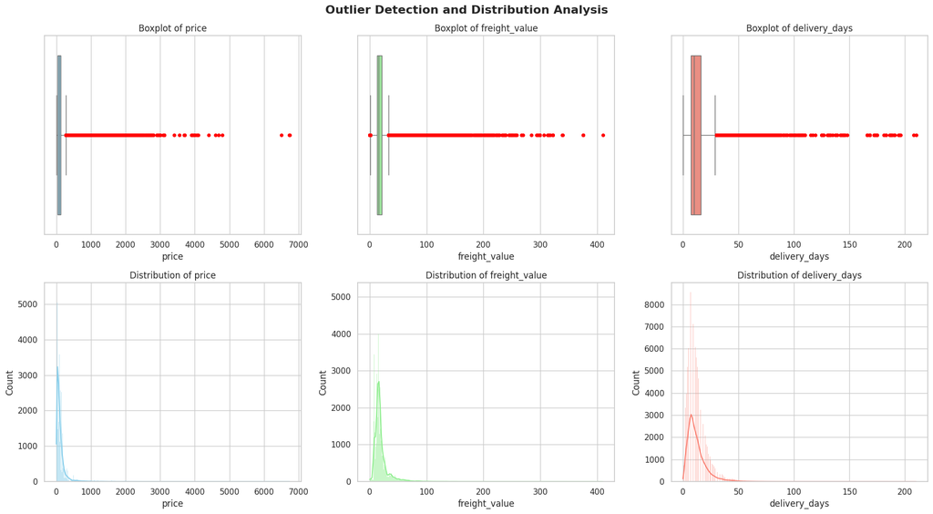

```python
import matplotlib.pyplot as plt
import seaborn as sns

# Numerical columns for outlier analysis
num_cols = ['price', 'freight_value', 'delivery_days']

# Colors for each variable
colors = ['skyblue', 'lightgreen', 'salmon']

# Create figure with 2 rows and 3 columns
fig, axes = plt.subplots(2, 3, figsize=(18, 10))

for i, col in enumerate(num_cols):

    # Boxplot
    sns.boxplot(
        x=data[col],
        ax=axes[0, i],
        color=colors[i],
        flierprops={
            'marker': 'o',
            'markerfacecolor': 'red',
            'markeredgecolor': 'red',
            'markersize': 4
        }
    )

    axes[0, i].set_title(f'Boxplot of {col}', fontsize=12)
    axes[0, i].set_xlabel(col)

    # Histogram + KDE
    sns.histplot(
        data=data,
        x=col,
        kde=True,
        ax=axes[1, i],
        color=colors[i]
    )

    axes[1, i].set_title(f'Distribution of {col}', fontsize=12)
    axes[1, i].set_xlabel(col)

plt.suptitle(
    'Outlier Detection and Distribution Analysis',
    fontsize=16,
    fontweight='bold'
)

plt.tight_layout()
plt.show()
```

*Calclating Outlier using IQR*

```python
num_cols = ['price', 'freight_value', 'delivery_days']

outlier_summary = {}

for col in num_cols:
    Q1 = data[col].quantile(0.25)
    Q3 = data[col].quantile(0.75)
    IQR = Q3 - Q1

    lower_bound = Q1 - 1.5 * IQR
    upper_bound = Q3 + 1.5 * IQR

    outlier_count = data[(data[col] < lower_bound) | (data[col] > upper_bound)].shape[0]

    outlier_summary[col] = {
        'Q1': Q1,
        'Q3': Q3,
        'IQR': IQR,
        'Lower Bound': lower_bound,
        'Upper Bound': upper_bound,
        'Outlier Count': outlier_count,
        'Outlier %': round(outlier_count / len(data) * 100, 2)
    }

outlier_summary_df = pd.DataFrame(outlier_summary).T
outlier_summary_df.round(2)
```

|  | Q1 | Q3 | IQR | Lower Bound | Upper Bound | Outlier Count | Outlier % |
| --- | --- | --- | --- | --- | --- | --- | --- |
| price | 39.90 | 134.17 | 94.27 | -101.50 | 275.57 | 8161.0 | 7.41 |
| freight_value | 13.08 | 21.15 | 8.07 | 0.98 | 33.25 | 11811.0 | 10.72 |
| delivery_days | 7.00 | 16.00 | 9.00 | -6.50 | 29.50 | 5236.0 | 4.75 |

### ⚓ Outlier Analysis

- Outliers were identified using the Interquartile Range (IQR) method for numerical features: price, freight_value, and delivery_days.
- Boxplots were used to visualize the distribution and detect extreme values.
- Several observations were found outside the IQR boundaries, particularly in product prices and freight charges.
- Upon investigation, these records were determined to represent genuine business transactions rather than data entry errors.
- Since high-value products, higher shipping costs, and longer delivery times are realistic scenarios in an e-commerce business, the outliers were retained for further analysis.
- Therefore, no outlier treatment or row removal was performed to preserve business insights and maintain data integrity.

### **Univariate Analysis**

*Numerical Variables Analysis*

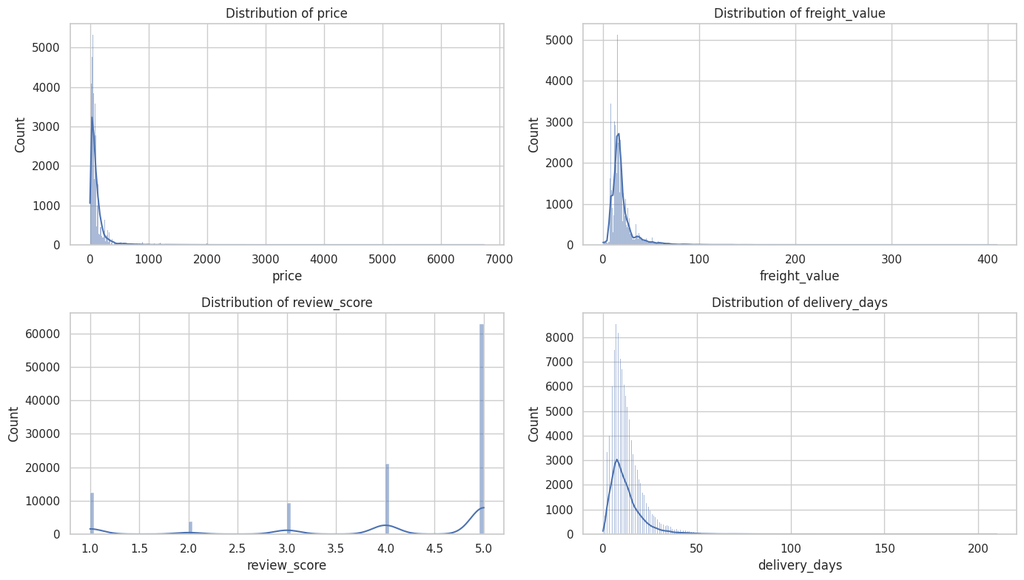

```python
numerical_cols = ['price','freight_value','review_score','delivery_days']

fig, axes = plt.subplots(2,2, figsize=(14,8))

for ax, col in zip(axes.flatten(), numerical_cols):
    sns.histplot(data[col], kde=True, ax=ax)
    ax.set_title(f'Distribution of {col}')

plt.tight_layout()
plt.show()
```

*Categorical Variables Analysis*

> Product Categories

|  | product_category_name | count |
| --- | --- | --- |
| 0 | cama_mesa_banho | 10953 |
| 1 | beleza_saude | 9465 |
| 2 | esporte_lazer | 8430 |
| 3 | moveis_decoracao | 8160 |
| 4 | informatica_acessorios | 7643 |
| 5 | utilidades_domesticas | 6795 |
| 6 | relogios_presentes | 5857 |
| 7 | telefonia | 4430 |
| 8 | ferramentas_jardim | 4268 |
| 9 | automotivo | 4139 |

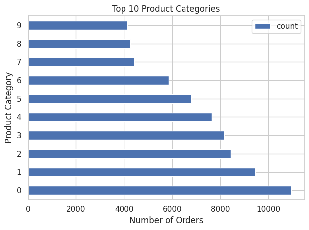

```python
top_categories = (
    data['product_category_name']
    .value_counts()
    .head(10).reset_index())
display(top_categories)

plt.figure(figsize=(12,6))

top_categories.plot(kind = 'barh'
)
plt.title('Top 10 Product Categories')
plt.xlabel('Number of Orders')
plt.ylabel('Product Category')
plt.tight_layout()
plt.show()
```

** 🔎 Observation**

- **Cama Mesa Banho** (Bed, Bath & Table) is the most purchased product category with over **9,000 orders**.
- Other highly popular categories include **Moveis Decoracao (Furniture & Decoration), Esporte Lazer (Sports & Leisure), and Beleza Saude (Beauty & Health)**.
- The top 10 categories account for a significant share of total platform sales.
- Demand is concentrated in household, lifestyle, beauty, and leisure-related products.

📊**Business Insight**

- Olist should prioritize inventory availability and seller onboarding within these high-demand categories.
- Marketing campaigns focused on these categories are likely to generate higher customer engagement and sales.
- Understanding why these categories perform well can help identify opportunities for expanding related product segments.

> Customer States

| customer_state | count |
| --- | --- |
| SP | 46441 |
| RJ | 14143 |
| MG | 12916 |
| RS | 6133 |
| PR | 5649 |
| SC | 4097 |
| BA | 3683 |
| DF | 2355 |
| GO | 2277 |
| ES | 2225 |

**dtype:** int64

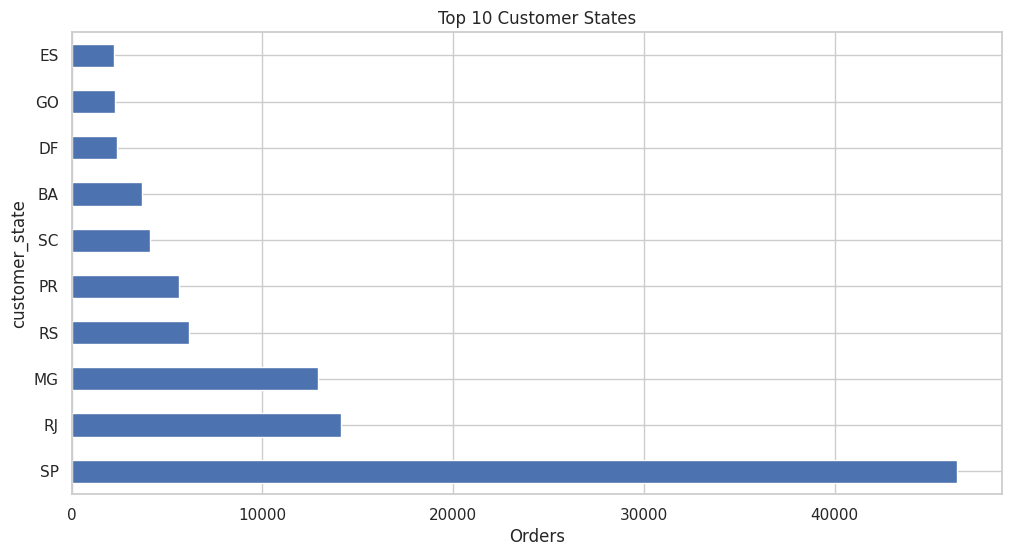

```python
top_states = data['customer_state'].value_counts().head(10)
display(top_states)
plt.figure(figsize=(12,6))
top_states.plot(kind = 'barh'
)
plt.title('Top 10 Customer States')
plt.xlabel('Orders')
plt.show()
```

**🔎 Observation**

- **São Paulo (SP)** contributes the highest number of orders by a large margin.
- **Rio de Janeiro (RJ) and Minas Gerais (MG)** are the second and third largest customer markets.
- The top customer states are concentrated in **Brazil's southeastern region**.
- Order volume drops significantly after the top three states.

**📊 Business Insight**

- São Paulo represents the most important market for Olist and should remain a primary focus for marketing and logistics investments.
- Regional warehouses and fulfillment centers near high-demand states can reduce delivery times and shipping costs.
- Lower-order states may present opportunities for customer acquisition campaigns and market expansion.

> Delayed Delivery Distribution

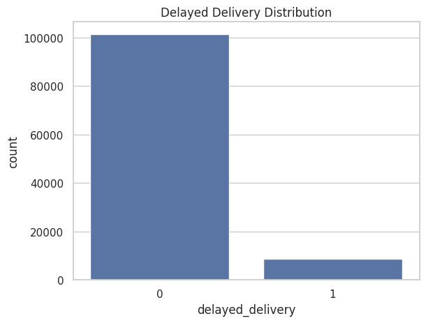

```
 ==Proportion==
```

|  | delayed_delivery | proportion |
| --- | --- | --- |
| 0 | 0 | 92.09177 |
| 1 | 1 | 7.90823 |

```python
sns.countplot(
    x='delayed_delivery',
    data=data
)
plt.title('Delayed Delivery Distribution')
plt.show()

print('\n ==Proportion==')

delay_pct = (data['delayed_delivery'].value_counts(normalize=True) * 100).reset_index()
display(delay_pct)
```

**🔎 Observation**

- The majority of orders were delivered on time (delayed_delivery = 0).
- Only a small proportion of orders experienced delivery delays (delayed_delivery = 1).
- This indicates that the logistics and fulfillment process was generally efficient.
- Delayed deliveries account for a relatively minor share of total orders, suggesting a high service level in terms of delivery performance.

**📊 Business Insight**

- Since most deliveries are completed on schedule, customer satisfaction is likely supported by reliable delivery operations.
- However, the delayed orders should be further investigated to identify potential causes such as seller processing delays, long shipping distances, or logistics bottlenecks.
- Reducing the delayed segment could further improve customer experience and review scores.

🎯 **Univariate Summary**

Overall, the univariate analysis reveals that customer demand is concentrated in a few key product categories and geographic regions. Bed, Bath & Table products emerged as the most popular category, while São Paulo accounted for the highest share of orders among all states. Additionally, the majority of orders were delivered on time, indicating efficient logistics operations. These findings suggest that Olist's business is driven by strong demand for household and lifestyle products, supported by a concentrated customer base in Brazil's southeastern region and a generally reliable delivery network.

### **Bivariate Analysis**

> *Review Score vs Delivery Days*

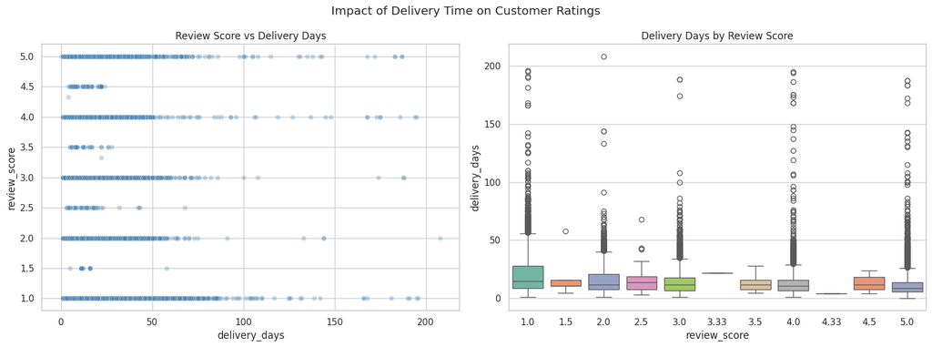

```python
fig, axes = plt.subplots(1, 2, figsize=(16, 6))

sns.scatterplot(
    data=data,
    x='delivery_days',
    y='review_score',
    alpha=0.3,
    color='steelblue',
    ax=axes[0]
)

axes[0].set_title('Review Score vs Delivery Days')

sns.boxplot(
    data=data,
    x='review_score',
    y='delivery_days',
    palette='Set2',
    ax=axes[1]
)

axes[1].set_title('Delivery Days by Review Score')

plt.suptitle('Impact of Delivery Time on Customer Ratings')
plt.tight_layout()
plt.show()
```

**🔎 Observation**

- Orders delivered within a shorter time period generally receive higher review scores.
- Extremely long delivery times (100+ days) are mostly associated with lower ratings.
- Although some customers still gave high ratings despite long deliveries, the overall trend suggests customer satisfaction decreases as delivery time increases.

**📊 Business Insights**

- Delivery speed is a key driver of customer satisfaction.
- Reducing delivery lead times can help improve customer ratings and overall customer experience.

> *Delayed Delivery vs Review Score*

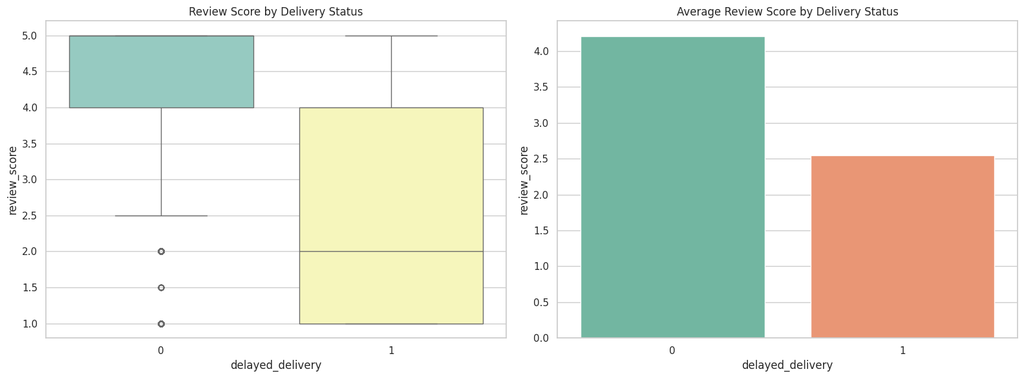

```python
fig, axes = plt.subplots(1, 2, figsize=(16, 6))

sns.boxplot(
    data=data,
    x='delayed_delivery',
    y='review_score',
    palette='Set3',
    ax=axes[0]
)

axes[0].set_title('Review Score by Delivery Status')

delay_review = (
    data.groupby('delayed_delivery')['review_score']
    .mean()
    .reset_index()
)

sns.barplot(
    data=delay_review,
    x='delayed_delivery',
    y='review_score',
    palette='Set2',
    ax=axes[1]
)

axes[1].set_title('Average Review Score by Delivery Status')

plt.tight_layout()
plt.show()
```

**🔎 Observations**

- Non-delayed orders have a significantly higher average review score (approx.4.2) compared to delayed orders (approx.2.5).
- The boxplot also shows delayed deliveries are associated with greater variability and lower customer ratings.

**📊 Business Insights**

- Delivery delays have a direct negative impact on customer satisfaction.
- Improving logistics efficiency and reducing late deliveries should be a priority for maintaining positive customer reviews.

> *Price vs Freight Value*

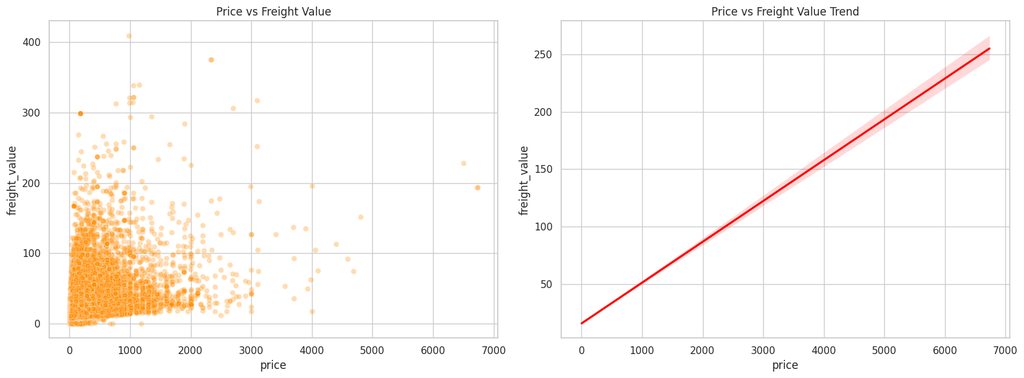

```python
fig, axes = plt.subplots(1, 2, figsize=(16, 6))

sns.scatterplot(
    data=data,
    x='price',
    y='freight_value',
    alpha=0.3,
    color='darkorange',
    ax=axes[0]
)

axes[0].set_title('Price vs Freight Value')

sns.regplot(
    data=data,
    x='price',
    y='freight_value',
    scatter=False,
    color='red',
    ax=axes[1]
)

axes[1].set_title('Price vs Freight Value Trend')

plt.tight_layout()
plt.show()
```

**🔎 Observations**

- A positive relationship exists between product price and freight cost.
- As product prices increase, shipping charges tend to increase as well.
- However, considerable variation exists, indicating factors such as weight, size, and delivery distance also influence freight costs.

**📊 Business Insights**

- Freight costs scale with product value but are not solely dependent on price.
- Optimizing shipping costs for high-value products can improve profitability and customer experience.

> *Customer State vs Average Delivery Days*

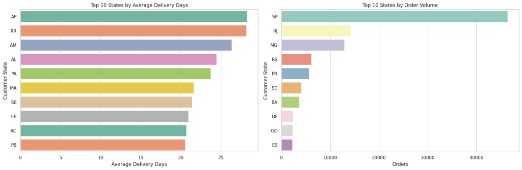

```python
state_delivery = (
    data.groupby('customer_state', observed=True)['delivery_days']
    .mean()
    .sort_values(ascending=False)
    .head(10)
    .reset_index()
)

state_orders = (
    data['customer_state']
    .value_counts()
    .head(10)
    .reset_index()
)

state_orders.columns = ['customer_state', 'orders']


state_delivery['customer_state'] = state_delivery['customer_state'].astype(str)
state_orders['customer_state'] = state_orders['customer_state'].astype(str)

fig, axes = plt.subplots(1, 2, figsize=(18, 6))

sns.barplot(
    data=state_delivery,
    x='delivery_days',
    y='customer_state',
    hue='customer_state',
    palette='Set2',
    legend=False,
    ax=axes[0]
)

axes[0].set_title('Top 10 States by Average Delivery Days')
axes[0].set_xlabel('Average Delivery Days')
axes[0].set_ylabel('Customer State')

sns.barplot(
    data=state_orders,
    x='orders',
    y='customer_state',
    hue='customer_state',
    palette='Set3',
    legend=False,
    ax=axes[1]
)

axes[1].set_title('Top 10 States by Order Volume')
axes[1].set_xlabel('Orders')
axes[1].set_ylabel('Customer State')

plt.tight_layout()
plt.show()
```

**🔎 Observations**

- States such as AP, RR, and AM experience the highest average delivery times.
- In contrast, states with the highest order volumes (SP, RJ, MG) do not necessarily have the longest delivery times.
- Major demand regions appear to benefit from a more efficient logistics network.

**📊 Business Insights**

- Delivery performance varies significantly across geographic regions.
- Olist may need to strengthen logistics infrastructure in remote states to reduce delivery times and improve service consistency.

> *Product Category vs Average Review Score*

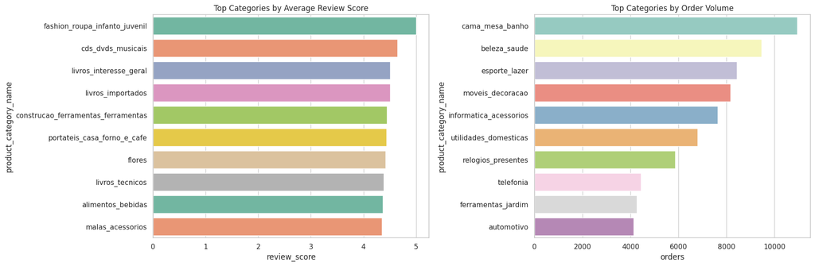

```python
category_review = (
    data.groupby('product_category_name')['review_score']
    .mean()
    .sort_values(ascending=False)
    .head(10)
    .reset_index()
)

category_orders = (
    data['product_category_name']
    .value_counts()
    .head(10)
    .reset_index()
)

category_orders.columns = ['product_category_name','orders']

category_review['product_category_name'] = category_review['product_category_name'].astype(str)
category_orders['product_category_name'] = category_orders['product_category_name'].astype(str)

fig, axes = plt.subplots(1, 2, figsize=(18, 6))

sns.barplot(
    data=category_review,
    x='review_score',
    y='product_category_name',
    palette='Set2',
    ax=axes[0]
)

axes[0].set_title('Top Categories by Average Review Score')

sns.barplot(
    data=category_orders,
    x='orders',
    y='product_category_name',
    palette='Set3',
    ax=axes[1]
)

axes[1].set_title('Top Categories by Order Volume')

plt.tight_layout()
plt.show()
```

**🔎 Observations**

- Categories such as fashion_roupa_infanto_juvenil, cds_dvds_musicais, and livros_interesse_geral receive the highest average review scores.
- Product categories with higher customer satisfaction are generally associated with lower complaint rates and better purchasing experiences.

**📊 Business Insights**

- High-rated categories represent strong-performing product segments and can be leveraged for customer retention and marketing campaigns.
- Understanding why these categories perform well can help improve lower-rated categories.

> *Product Category vs Average Delivery Days*

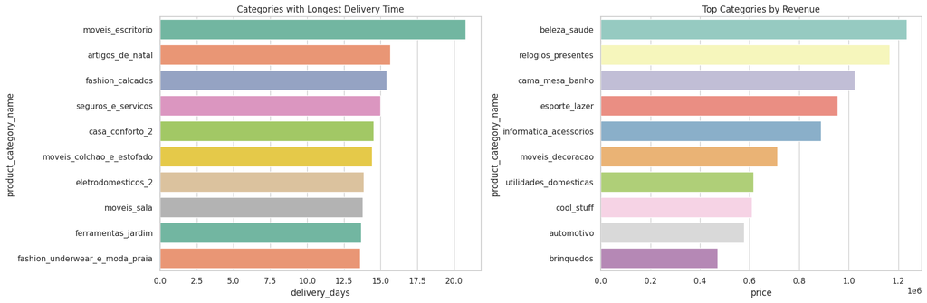

```python
category_delivery = (
    data.groupby('product_category_name')['delivery_days']
    .mean()
    .sort_values(ascending=False)
    .head(10)
    .reset_index()
)

category_revenue = (
    data.groupby('product_category_name')['price']
    .sum()
    .sort_values(ascending=False)
    .head(10)
    .reset_index()
)

category_delivery['product_category_name'] = category_delivery['product_category_name'].astype(str)
category_revenue['product_category_name'] = category_revenue['product_category_name'].astype(str)

fig, axes = plt.subplots(1, 2, figsize=(18, 6))

sns.barplot(
    data=category_delivery,
    x='delivery_days',
    y='product_category_name',
    palette='Set2',
    ax=axes[0]
)

axes[0].set_title('Categories with Longest Delivery Time')

sns.barplot(
    data=category_revenue,
    x='price',
    y='product_category_name',
    palette='Set3',
    ax=axes[1]
)

axes[1].set_title('Top Categories by Revenue')

plt.tight_layout()
plt.show()
```

**🔎 Observations**

- Categories such as moveis_escritorio and artigos_de_natal exhibit the longest average delivery times.
- Furniture-related categories generally require longer delivery periods due to size and handling complexity.
- Revenue-generating categories are not always the fastest to deliver.

**📊 Business Insights**

- Large and bulky product categories pose logistics challenges that increase delivery time.
- Improving fulfillment efficiency for these categories could reduce delays and enhance customer satisfaction while protecting revenue.

**🎯 Bivariate Summary**

The bivariate analysis reveals that delivery performance plays a crucial role in customer satisfaction. Delayed deliveries are strongly associated with lower review scores, while faster deliveries generally lead to better customer experiences. Geographic location and product category significantly influence delivery times, highlighting opportunities for logistics optimization. Additionally, freight costs increase with product value, and certain product categories consistently achieve higher customer ratings, indicating areas of strong business performance. These findings suggest that improving delivery efficiency and focusing on high-performing product categories can enhance both customer satisfaction and business outcomes.

### **Multivariate Analysis**

*Correlation Matrix*

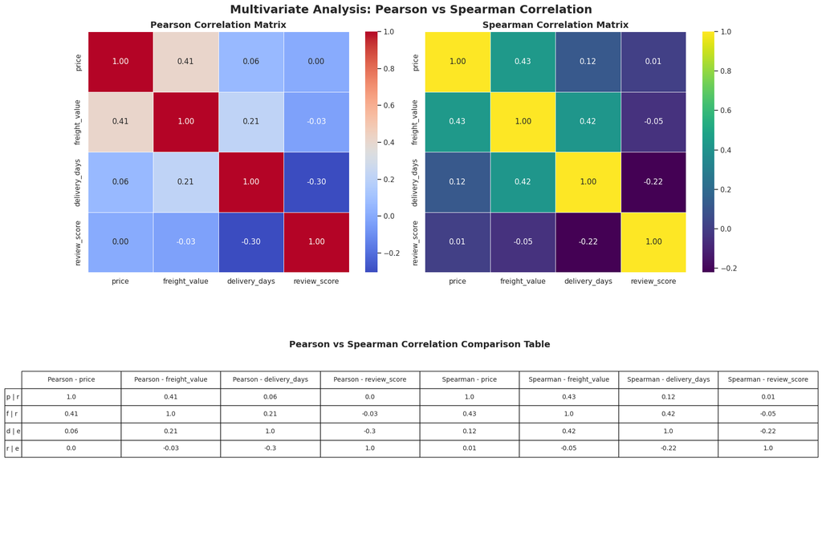

```python
# Variables for correlation analysis
corr_cols = [
    'price',
    'freight_value',
    'delivery_days',
    'review_score'
]

# Correlation matrices
pearson_corr = data[corr_cols].corr(method='pearson')
spearman_corr = data[corr_cols].corr(method='spearman')

# Combined comparison table
corr_comparison = pd.concat(
    {
        'Pearson': pearson_corr.round(2),
        'Spearman': spearman_corr.round(2)
    },
    axis=1
)

# Figure layout
fig = plt.figure(figsize=(18, 12))

# Pearson Heatmap
ax1 = plt.subplot2grid((2, 2), (0, 0))

sns.heatmap(
    pearson_corr,
    annot=True,
    fmt='.2f',
    cmap='coolwarm',
    linewidths=0.5,
    annot_kws={'size':12},
    ax=ax1
)

ax1.set_title(
    'Pearson Correlation Matrix',
    fontsize=14,
    fontweight='bold'
)

# Spearman Heatmap
ax2 = plt.subplot2grid((2, 2), (0, 1))

sns.heatmap(
    spearman_corr,
    annot=True,
    fmt='.2f',
    cmap='viridis',
    linewidths=0.5,
    annot_kws={'size':12},
    ax=ax2
)

ax2.set_title(
    'Spearman Correlation Matrix',
    fontsize=14,
    fontweight='bold'
)

# Comparison Table
ax3 = plt.subplot2grid((2, 2), (1, 0), colspan=2)

ax3.axis('off')

table = ax3.table(
    cellText=corr_comparison.values,
    rowLabels=[
        f"{idx[0]} | {idx[1]}"
        for idx in corr_comparison.index
    ],
    colLabels=[
        f"{lvl0} - {lvl1}"
        for lvl0, lvl1 in corr_comparison.columns
    ],
    loc='center',
    cellLoc='center'
)

table.auto_set_font_size(False)
table.set_fontsize(10)
table.scale(1.2, 1.8)

ax3.text(
    0.5,
    0.77,
    'Pearson vs Spearman Correlation Comparison Table',
    ha='center',
    va='bottom',
    fontsize=14,
    fontweight='bold',
    transform=ax3.transAxes
)


plt.suptitle(
    'Multivariate Analysis: Pearson vs Spearman Correlation',
    fontsize=18,
    fontweight='bold'
)

plt.tight_layout()
plt.show()
```

**🔎 Observations**

**📊 Business Insights**

- Improving delivery speed can have a positive impact on customer ratings.
- Shipping costs tend to increase with product value, highlighting the importance of logistics optimization.
- Delivery performance remains one of the most important operational drivers of customer satisfaction.
- The similarity between Pearson and Spearman results increases confidence in the stability of these business relationships.

### **🧪 Hypothesis Testing: Impact of Delayed Delivery on Review Score**

> *Prepare the data*

```python
# Drop missing review scores
hyp_data = data[['delayed_delivery', 'review_score']].dropna()

on_time = hyp_data[hyp_data['delayed_delivery'] == 0]['review_score']
delayed = hyp_data[hyp_data['delayed_delivery'] == 1]['review_score']

print("On-time orders:", len(on_time))
print("Delayed orders:", len(delayed))
print("On-time mean review:", round(on_time.mean(), 2))
print("Delayed mean review:", round(delayed.mean(), 2))
```

```
On-time orders: 100843
Delayed orders: 8519
On-time mean review: 4.21
Delayed mean review: 2.55
```

**📈 Descriptive Statistic**

| **Delivery Status** | **Orders** | **Average View Score** |
| --- | --- | --- |
| On-Time | 100,843 | 4.21 |
| Delayed | 8,519 | 2.55 |

> *Define hypothesis*
- Null Hypothesis(H<sub>0</sub>): There is no significant difference in average review score between on-time and delayed deliveries.
- Alternative Hypothesis(H<sub>a</sub>): There is a significant difference in average review score between on-time and delayed deliveries.

**🤔 Why Shapiro-Wilk Test Was Not Used?**

The dataset contains more than 100,000 observations. For very large datasets, the Shapiro-Wilk test becomes extremely sensitive and often detects even minor deviations from normality as statistically significant. As a result, it may reject the normality assumption even when the distribution is sufficiently close to normal for practical purposes.

Instead, Q-Q plots were used to visually assess normality. Furthermore, due to the large sample size, the Central Limit Theorem ensures that the sampling distribution of the mean is approximately normal, making Welch's t-test a reliable choice for hypothesis testing.

> *Checking normality using Q-Q plot*

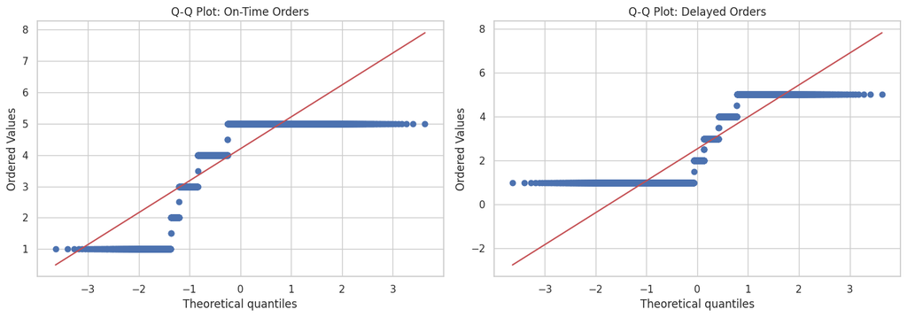

```python
# Sampling for Q-Q plot
sample_on_time = on_time.sample(5000, random_state=42)
sample_delayed = delayed.sample(min(5000, len(delayed)), random_state=42)

fig, axes = plt.subplots(1, 2, figsize=(14, 5))

stats.probplot(sample_on_time, dist="norm", plot=axes[0])
axes[0].set_title("Q-Q Plot: On-Time Orders")

stats.probplot(sample_delayed, dist="norm", plot=axes[1])
axes[1].set_title("Q-Q Plot: Delayed Orders")

plt.tight_layout()
plt.show()
```

**▶ Q-Q Plot Interpretation**

The Q-Q plots indicate that review scores are not perfectly normally distributed, as the observed points deviate from the reference line, particularly in the tails. This behavior is expected because review scores are discrete ratings ranging from 1 to 5 rather than continuous measurements.

Despite the departure from normality, the large sample size allows the use of parametric tests under the Central Limit Theorem. Therefore, the analysis proceeds with variance testing and Welch's t-test.

> *Check equal variance using Levene’s Test*
- Null Hypothesis(H<sub>0</sub>): Homogenous Variance.
- Alternative Hypothesis(H<sub>a</sub>): Non Homogeneous.

**Significance level(α) = 0.05**

```python
alpha = 0.05
levene_stat, levene_p = stats.levene(on_time, delayed)

print("Levene Statistic:", round(levene_stat, 4))
print("Levene P-value:", levene_p)

if levene_p < alpha:
    print("Variances are significantly different. Use Welch's t-test.")
else:
    print("Variances are not significantly different. Student's t-test can be used.")
```

```
Levene Statistic: 2611.7858
Levene P-value: 0.0
Variances are significantly different. Use Welch's t-test.
```

**▶ Levene's Test Interpretation**

Levene's test returned a *p*-value below 0.05, indicating that the variances of review scores between on-time and delayed deliveries are significantly different. Since the assumption of equal variances is violated, Welch's t-test was selected instead of the standard Student's t-test.

> **Welch’s t-test**

```python
t_stat, p_value = stats.ttest_ind(
    on_time,
    delayed,
    equal_var=False
)

print("T-statistic:", round(t_stat, 4))
print("P-value:", p_value)

alpha = 0.05

if p_value < alpha:
    print("Reject H0: Delayed delivery significantly affects review score.")
else:
    print("Fail to reject H0: No significant difference found.")
```

```
T-statistic: 90.3646
P-value: 0.0
Reject H0: Delayed delivery significantly affects review score.
```

*▶ Since the *p*-value is significantly lower than the significance level (α = 0.05), the null hypothesis is rejected.*

**🎯 Conclusion**

Delayed deliveries have a statistically significant negative impact on customer review scores. Customers whose orders were delivered late provided substantially lower ratings (average score: 2.55) compared to customers whose orders arrived on time (average score: 4.21).

This finding highlights delivery performance as one of the most important drivers of customer satisfaction on the Olist platform. Improving delivery reliability could lead to higher customer ratings, improved customer retention, and a better overall shopping experience.

### **🏳 Conclusion**

This analysis of the Olist Brazilian E-commerce dataset provided valuable insights into customer behavior, delivery performance, and operational efficiency. The findings indicate that delivery reliability is one of the most important drivers of customer satisfaction, with delayed deliveries significantly reducing review scores. Product pricing, freight costs, and delivery times were found to be interconnected, while customer demand remained concentrated in a few key product categories and geographic regions.